# Assignment 1 - Clean, Map to HUGO Symbol, and Normalize Data

Joelle Jee

## General Plublication Information

Publication Title: Disruption of the MBD2-NuRD complex but not MBD3-NuRD induces high level HbF expression in human adult erythroid cells  
Publication Date: 2019 Dec  
Publication Journal: Haematologica  
GEOID: GSE121992  
This study was able to prove that the Nucleosome Remodeling and Deacetylase complex member MBD2 knock-out in primary human erythroid cells were able to significantly elevate the gamma/gamma+beta mRNA expresssion of HbF, which is known in the literature to benefit sickle cell anemia patients.  
They performed RNA-sequencing of the MBD2KO and the control (sgCSR) cells before and after differentiation to measure the effect of deficiency of MBD in erythroid differentiation.  
They found that MBD2KO in primary human erythroid cells significantly elevate the gamma/gamma+beta mRNA expresssion of HbF without changing the morphological appearance after differentiation compared to controls. From this finding, the authors proposed that therapies targeting MBD2 can ameliorate the underlying pathophysiological defects in sickle cell anemia and beta (beta)-thalassemia.

## Load required packages

We will first load the required packages to clean, normalize and interpret the data.

```r
knitr::opts_chunk$set(warning = FALSE)

if (!requireNamespace("BiocManager", quietly = TRUE)) {
  install.packages("BiocManager")
}

if (!requireNamespace("GEOquery", quietly = TRUE)) {
  BiocManager::install("GEOquery")
}

if (!requireNamespace("biomaRt", quietly = TRUE)) {
  BiocManager::install("biomaRt")
}

if (!requireNamespace("edgeR", quietly = TRUE)) {
  BiocManager::install("edgeR")
}
```

## Download the Datset

Download the dataset (GEO accession: GSE121992) using package GEOquery.

```r
HbF_gse <- GEOquery::getGEO("GSE121992", GSEMatrix = FALSE)
HbF_gpl <- names(GEOquery::GPLList(HbF_gse))[1]
HbF_gpl_info <- GEOquery::Meta(GEOquery::getGEO(HbF_gpl))
```

### Platform Information

**Title of Platform:** Illumina HiSeq 2500 (Homo sapiens)  
**Submission Date:** Mar 14 2013  
**Last Update Date:** Mar 27 2019  
**Organism:** Homo sapiens  
**Number of GEO datasets using this study:** 5972  
**NUmber of GEO samples using this study:** 161580

## Download the Supplementary Files

Observe the how the dataset was sampled by defining the groups.

```r
sfiles = GEOquery::getGEOSuppFiles('GSE121992')
fnames = rownames(sfiles)
# there is only one supplemental file
HbF_exp <- read.delim(fnames[1],
                      header = TRUE,
                      check.names = FALSE,
                      skip = 1)

samples <- c(replicate(3, "sgSCR_pre"),
             replicate(3, "MBD2KO_pre"),
             replicate(3, "sgSCR_post"),
             replicate(3, "MBD2KO_post"))

repNum <- c("1", "2", "3", "1", "2", "3", "1", "2", "3", "1", "2", "3")

samples <- data.frame(samples, repNum)

samples_row <- lapply(colnames(HbF_exp[7:18]),
                      function(x) {
                        sample_name <- unlist(strsplit(x, split = "\\/"))[2]
                        sample_name <- unlist(strsplit(sample_name, split = "_"))[2]
                        return(sample_name)
                      })

rownames(samples) <- samples_row
colnames(samples) <- c("cell type", "replication")

samples
```

|  | cell type | replication |
| --- | --- | --- |
| S5 | sgSCR_pre | 1 |
| S6 | sgSCR_pre | 2 |
| S7 | sgSCR_pre | 3 |
| S8 | MBD2KO_pre | 1 |
| S9 | MBD2KO_pre | 2 |
| S10 | MBD2KO_pre | 3 |
| S11 | sgSCR_post | 1 |
| S12 | sgSCR_post | 2 |
| S13 | sgSCR_post | 3 |
| S14 | MBD2KO_post | 1 |

[output cut: 2 more lines]

## Data Filtering and Normalizing

### Filtering weakly expressed and noninformative features

Abiding by edgeR, remove features without at least 1 read per million in n of the samples, where n is the size of thes smallest group of repicates. Here n equals to 3.

```r
# calculate the counts per million using the edgeR package function cpm
cpms <- edgeR::cpm(HbF_exp[, 7:18])
rownames(cpms) <- HbF_exp[, 1]

# now drop the genes with low counts
keep <- rowSums(cpms > 1) >= 3
HbF_exp_filtered <- HbF_exp[keep,]

# number of unimportant genes dropped:
num_removed <- dim(HbF_exp)[1] - dim(HbF_exp_filtered)[1]

num_removed
```

```
## [1] 43394
```

### Filtering missing genes

#### Map the GeneId to Hugo gene symbols

We will be using the package Biomart to map the Human Ensembl Gene Ids to HGNC gene symbols.

```r
# first need to convert the ensembl id versions to simply ensembl id
# because low match count with ensemble_id_version to hgnc_symbol
char_HbF_id <- as.character(HbF_exp_filtered$Geneid)
ensembl_id <- lapply(char_HbF_id,
                     function(x) {
                       return(unlist(strsplit(x,"\\."))[1])
                     })
ensembl_id <- unlist(ensembl_id)
HbF_exp_filtered$Geneid <- ensembl_id

# check first to see if HbF_id_conversions.rds exists
conversion_stash <- "HbF_id_conversion.rds"
if (file.exists(conversion_stash)) {
  HbF_id_conversion <- readRDS(conversion_stash)
} else {
  # define ensembl
  ensembl <- biomaRt::useMart("ensembl",
                              dataset = "hsapiens_gene_ensembl",
                              host="uswest.ensembl.org",
                              ensemblRedirect = FALSE)
  # using ensembl match the gene ids in our dataset to
  # HUGO gene symbols
  HbF_id_conversion <- biomaRt::getBM(attributes = c("ensembl_gene_id","hgnc_symbol"),
                                 filters = "ensembl_gene_id",
                                 values = HbF_exp_filtered$Geneid,
                                 mart = ensembl)
  # save the file to decrease computationtime in the future
  saveRDS(HbF_id_conversion, conversion_stash)
}

HbF_id_conversion[1:5,]
```

|  | ensembl_gene_id | hgnc_symbol |
| --- | --- | --- |
| 1 | ENSG00000001460 | STPG1 |
| 2 | ENSG00000001461 | NIPAL3 |
| 3 | ENSG00000004455 | AK2 |
| 4 | ENSG00000004487 | KDM1A |
| 5 | ENSG00000007923 | DNAJC11 |

Let’s see how many genes ids were not matched to a gene name.

```r
# merge HbF_id_conversion to HbF_exp_filtered by gene ids
counts_annot <- merge(HbF_id_conversion,
                      HbF_exp_filtered,
                      by.x = 1,
                      by.y = 1,
                      all.y = TRUE)

# the rows without a match will say NA for gene name
counts_annot[counts_annot == ""] <- NA
missing_gene <- counts_annot$ensembl_gene_id[which(is.na(counts_annot$hgnc_symbol))]
# percentage of missing genes
length(missing_gene)/nrow(counts_annot)
```

```
## [1] 0.1551875
```

Remove missing genes although its 15% because our original dataset does not provide gene names. If our original dataset provided gene names, even if some gen ids did not map to HUGO gene symbols, we would’ve been able to use outdated gene symbols. But that is not an option in this case.

```r
HbF_id_conversion[HbF_id_conversion == ""] <- NA
# simply remove the unmatched rows by setting all.y = FALSE
mapped_genes <- merge(HbF_id_conversion,
                      HbF_exp_filtered,
                      by.x = 1,
                      by.y = 1,
                      all.y = FALSE)

mapped_genes[1:5, 8:19]
```

|  | 03_sorted/1_S5_L003_R1_001_paired.fastq.gz.bam | 03_sorted/2_S6_L003_R1_001_paired.fastq.gz.bam | 03_sorted/3_S7_L003_R1_001_paired.fastq.gz.bam | 03_sorted/4_S8_L003_R1_001_paired.fastq.gz.bam | 03_sorted/5_S9_L003_R1_001_paired.fastq.gz.bam | 03_sorted/6_S10_L003_R1_001_paired.fastq.gz.bam | 03_sorted/7_S11_L003_R1_001_paired.fastq.gz.bam | 03_sorted/8_S12_L003_R1_001_paired.fastq.gz.bam | 03_sorted/9_S13_L003_R1_001_paired.fastq.gz.bam | 03_sorted/10_S14_L003_R1_001_paired.fastq.gz.bam | 03_sorted/11_S15_L003_R1_001_paired.fastq.gz.bam | 03_sorted/12_S16_L003_R1_001_paired.fastq.gz.bam |
| --- | --- | --- | --- | --- | --- | --- | --- | --- | --- | --- | --- | --- |
| 1 | 157 | 199 | 113 | 218 | 183 | 187 | 44 | 62 | 36 | 24 | 52 | 22 |
| 2 | 709 | 951 | 578 | 893 | 648 | 646 | 581 | 749 | 520 | 483 | 494 | 338 |
| 3 | 220 | 244 | 187 | 262 | 184 | 209 | 210 | 232 | 163 | 170 | 173 | 118 |
| 4 | 481 | 579 | 428 | 522 | 366 | 410 | 481 | 591 | 438 | 312 | 326 | 242 |
| 5 | 947 | 1306 | 927 | 1123 | 874 | 922 | 506 | 607 | 399 | 322 | 337 | 253 |

Let’s see if each ensemble gene id uniquely maps to a gene name.

```r
num_unique <- length(unique(mapped_genes$hgnc_symbol))
num_unique == length(unique(mapped_genes$ensembl_gene_id))
```

```
## [1] FALSE
```

NO it is not. For multiple geneids mapping to the same gene name, we will take the average count.

```r
length(unique(mapped_genes$ensembl_gene_id))
```

```
## [1] 16932
```

```r
length(mapped_genes$ensembl_gene_id)
```

```
## [1] 16932
```

We only have multiple gene ids mapping to same gene names and not the other way around.  
To take this problem into account, we will take the average of the gene counts by the name.

```r
# compute the average count for each sample group by gene name
a <- aggregate(mapped_genes[, 8:19],
               list(mapped_genes$hgnc_symbol),
               mean)

# call it mapped_genes and name the rows by the unique gene names
mapped_genes <- a[,2:13]
rownames(mapped_genes) <- a[, 1]


# change the column names of mapped_genes to sample
# names for readability of the graph
col_names <- lapply(rownames(samples),
                    function(x) {
                      cell_type <- as.character(samples[x,1])
                      rep <- as.character(samples[x, 2])
                      name <- paste(cell_type, rep, sep = "_r")
                    })

colnames(mapped_genes) <- unlist(col_names)

mapped_genes[1:5,]
```

|  | sgSCR_pre_r1 | sgSCR_pre_r2 | sgSCR_pre_r3 | MBD2KO_pre_r1 | MBD2KO_pre_r2 | MBD2KO_pre_r3 | sgSCR_post_r1 | sgSCR_post_r2 | sgSCR_post_r3 | MBD2KO_post_r1 | MBD2KO_post_r2 | MBD2KO_post_r3 |
| --- | --- | --- | --- | --- | --- | --- | --- | --- | --- | --- | --- | --- |
| A2M | 17 | 17 | 14 | 19 | 10 | 19 | 23 | 32 | 32 | 25 | 19 | 20 |
| A2ML1 | 11 | 15 | 8 | 11 | 5 | 9 | 8 | 10 | 9 | 13 | 22 | 12 |
| A4GALT | 130 | 231 | 163 | 292 | 218 | 194 | 272 | 355 | 237 | 171 | 228 | 160 |
| AAAS | 87 | 130 | 88 | 111 | 127 | 72 | 173 | 203 | 132 | 118 | 151 | 130 |
| AACS | 527 | 768 | 580 | 354 | 326 | 281 | 507 | 590 | 440 | 192 | 225 | 171 |

Final coverage of out data is:

```r
nrow(mapped_genes)
```

```
## [1] 14436
```

### Normalize Data with Trimmed Mean of M-values

We will be using Trimmed MEan of M-values (TMM) to normalize out data. It is a way of computing the average of data excluding the extremes of the data points. This method also does not require modification prior to normalization. Using R package edgeR, we can compute normalize data using TMM very easily.  
First Create an edgeR container for RNASeq count data.

```r
filtered_data_matrix <- as.matrix(mapped_genes)
rownames(filtered_data_matrix) <- rownames(mapped_genes)

d <- edgeR::DGEList(counts = filtered_data_matrix,
                   group = samples$cell.type)

d[1:5, ]
```

```
## An object of class "DGEList"
## $counts
##        sgSCR_pre_r1 sgSCR_pre_r2 sgSCR_pre_r3 MBD2KO_pre_r1 MBD2KO_pre_r2
## A2M              17           17           14            19            10
## A2ML1            11           15            8            11             5
## A4GALT          130          231          163           292           218
## AAAS             87          130           88           111           127
## AACS            527          768          580           354           326
##        MBD2KO_pre_r3 sgSCR_post_r1 sgSCR_post_r2 sgSCR_post_r3 MBD2KO_post_r1
## A2M               19            23            32            32             25
## A2ML1              9             8            10             9             13
## A4GALT           194           272           355           237            171
## AAAS              72           173           203           132            118
## AACS             281           507           590           440            192
##        MBD2KO_post_r2 MBD2KO_post_r3
## A2M                19             20
## A2ML1              22             12
## A4GALT            228            160
## AAAS              151            130
## AACS              225            171
##
## $samples
##               group lib.size norm.factors
## sgSCR_pre_r1      1  9483595            1
## sgSCR_pre_r2      1 12901299            1
## sgSCR_pre_r3      1  9018163            1
## MBD2KO_pre_r1     1 12424211            1
## MBD2KO_pre_r2     1  9863992            1
## 7 more rows ...
```

Then calculate the normalization factors.

```r
d <- edgeR::calcNormFactors(d)

d[1:5,]
```

```
## An object of class "DGEList"
## $counts
##        sgSCR_pre_r1 sgSCR_pre_r2 sgSCR_pre_r3 MBD2KO_pre_r1 MBD2KO_pre_r2
## A2M              17           17           14            19            10
## A2ML1            11           15            8            11             5
## A4GALT          130          231          163           292           218
## AAAS             87          130           88           111           127
## AACS            527          768          580           354           326
##        MBD2KO_pre_r3 sgSCR_post_r1 sgSCR_post_r2 sgSCR_post_r3 MBD2KO_post_r1
## A2M               19            23            32            32             25
## A2ML1              9             8            10             9             13
## A4GALT           194           272           355           237            171
## AAAS              72           173           203           132            118
## AACS             281           507           590           440            192
##        MBD2KO_post_r2 MBD2KO_post_r3
## A2M                19             20
## A2ML1              22             12
## A4GALT            228            160
## AAAS              151            130
## AACS              225            171
##
## $samples
##               group lib.size norm.factors
## sgSCR_pre_r1      1  9483595     1.019650
## sgSCR_pre_r2      1 12901299     1.042066
## sgSCR_pre_r3      1  9018163     1.058364
## MBD2KO_pre_r1     1 12424211     1.019094
## MBD2KO_pre_r2     1  9863992     1.046935
## 7 more rows ...
```

Estimate common and tagwise dispersion using edgeR. Dispersion is a measuret of how much the variance deviates from the mean; and common and tagwise dispersion calculates a common dispersion value for all genes, and gene-specific dispersion.

```r
model_design <- model.matrix(~samples$replication + samples$`cell type`+0)
d <- edgeR::estimateDisp(d, model_design)
norm_counts <- edgeR::cpm(d)

norm_counts[1:5,]
```

```
##        sgSCR_pre_r1 sgSCR_pre_r2 sgSCR_pre_r3 MBD2KO_pre_r1 MBD2KO_pre_r2
## A2M        1.758024     1.264505    1.4668128     1.5006191     0.9683397
## A2ML1      1.137545     1.115739    0.8381788     0.8687795     0.4841698
## A4GALT    13.443712    17.182385   17.0778921    23.0621461    21.1098051
## AAAS       8.996946     9.669740    9.2199663     8.7667747    12.2979140
## AACS      54.498739    57.125851   60.7679598    27.9589032    31.5678737
##        MBD2KO_pre_r3 sgSCR_post_r1 sgSCR_post_r2 sgSCR_post_r3 MBD2KO_post_r1
## A2M        1.8721817     2.4074203     2.5885862      3.756041       3.285409
## A2ML1      0.8868229     0.8373636     0.8089332      1.056386       1.708413
## A4GALT    19.1159607    28.4703613    28.7171282     27.818176      22.472195
## AAAS       7.0945833    18.1079872    16.4213438     15.493668      15.507129
## AACS      27.6885822    53.0679161    47.7270582     51.645559      25.231939
##        MBD2KO_post_r2 MBD2KO_post_r3
## A2M          2.281152       3.124706
## A2ML1        2.641334       1.874823
## A4GALT      27.373824      24.997644
## AAAS        18.129155      20.310586
## AACS        27.013642      26.716232
```

Graph the biological coefficient of variation(BCV), which is squared of dspersion.

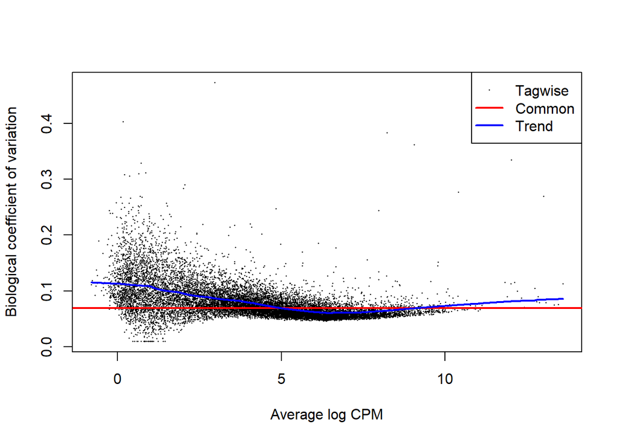

```r
edgeR::plotBCV(d, col.tagwise = "black", col.common = "red")
```

Visualize the representation of the mean-variance relationship.

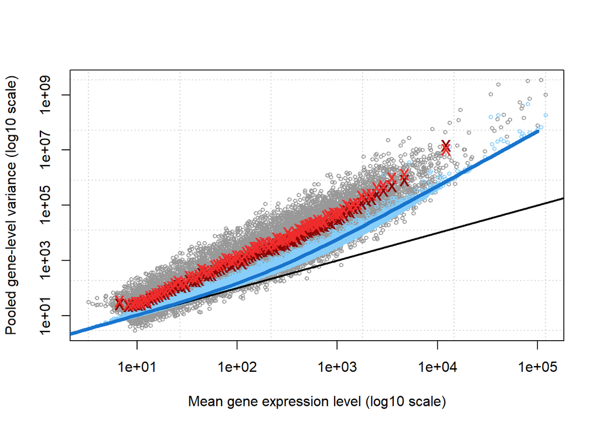

```r
edgeR::plotMeanVar(d, show.raw.vars = TRUE,
                   show.tagwise.vars = TRUE,
                   NBline = TRUE,
                   show.ave.raw.vars = TRUE,
                   show.binned.common.disp.vars = TRUE)
```

## Visualization of Normalized vs unNormalized Data

### Boxplot

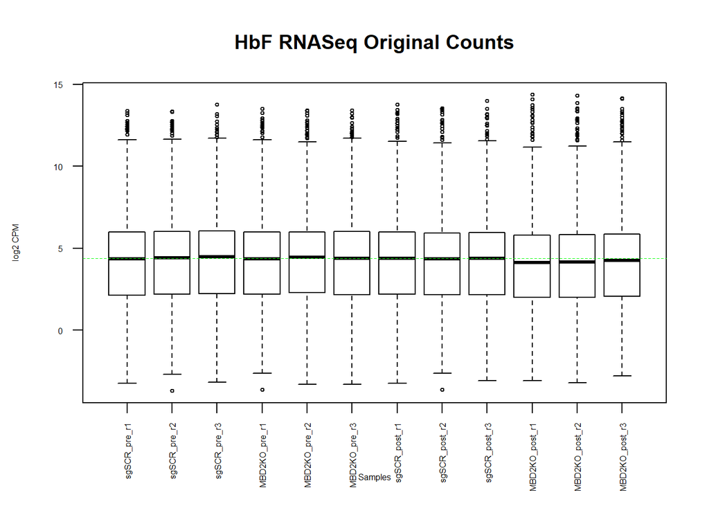

```r
# BOXPLOT FOR UNNORMLIZED DATA
data2plot <- log2(edgeR::cpm(mapped_genes))
boxplot(data2plot, xlab = "Samples", ylab = "log2 CPM",
        las = 2, cex = 0.5, cex.lab = 0.5,
        cex.axis = 0.5, main = "HbF RNASeq Original Counts")

abline(h = median(apply(data2plot, 2, median)),
       col = "green",
       lwd = 0.6,
       lty = "dashed")
```

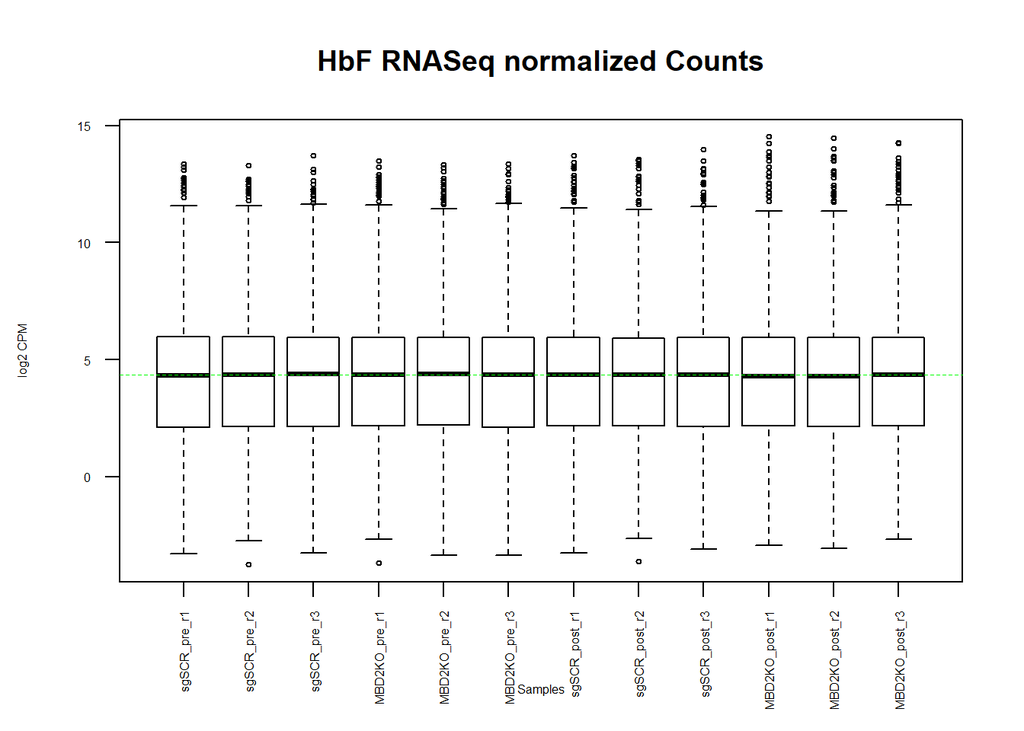

```r
# BOXPLOT FOR NORMALIZED DATA
norm_data2plot <- log2(norm_counts)
boxplot(norm_data2plot, xlab = "Samples", ylab = "log2 CPM",
        las = 2, cex = 0.5, cex.lab = 0.5,
        cex.axis = 0.5, main = "HbF RNASeq normalized Counts")

abline(h = median(apply(norm_data2plot, 2, median)),
       col = "green",
       lwd = 0.6,
       lty = "dashed")
```

### Density plot

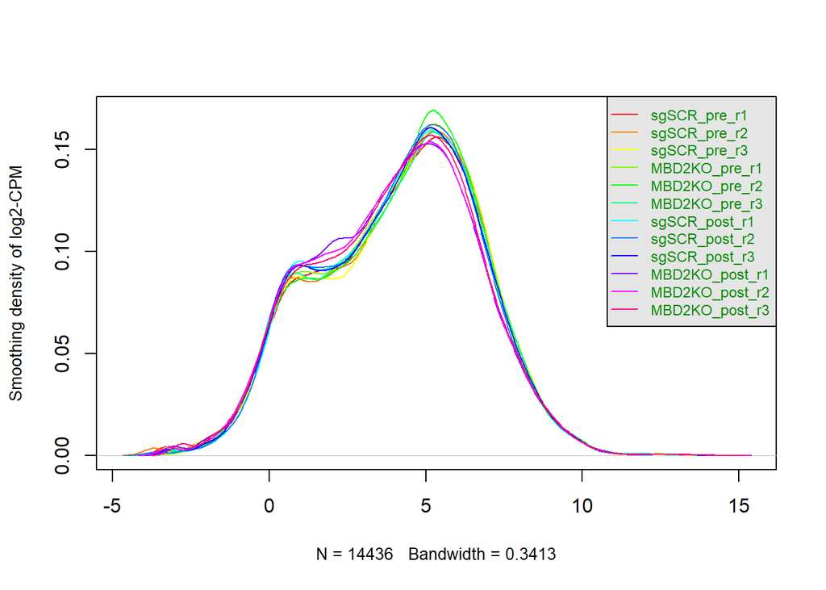

```r
# DENSITY PLOT FOR UNNORMALIZED DATA
counts_density <- apply(log2(edgeR::cpm(mapped_genes)),
                        2,
                        density)
#calculate the limits across all the samples
xlim <- 0; ylim <- 0
for (i in 1:length(counts_density)) {
  xlim <- range(c(xlim, counts_density[[i]]$x));
  ylim <- range(c(ylim, counts_density[[i]]$y))
}
cols <- rainbow(length(counts_density))
ltys <- rep(1, length(counts_density))
#plot the first density plot to initialize the plot
plot(counts_density[[1]], xlim=xlim, ylim=ylim, type="n",
     ylab="Smoothing density of log2-CPM", main="", cex.lab = 0.85)
#plot each line
for (i in 1:length(counts_density)) {
  lines(counts_density[[i]], col=cols[i], lty=ltys[i])
}
#create legend
legend("topright", colnames(data2plot),
       col=cols, lty=ltys, cex=0.75,
       border ="blue",  text.col = "green4",
       merge = TRUE, bg = "gray90")
```

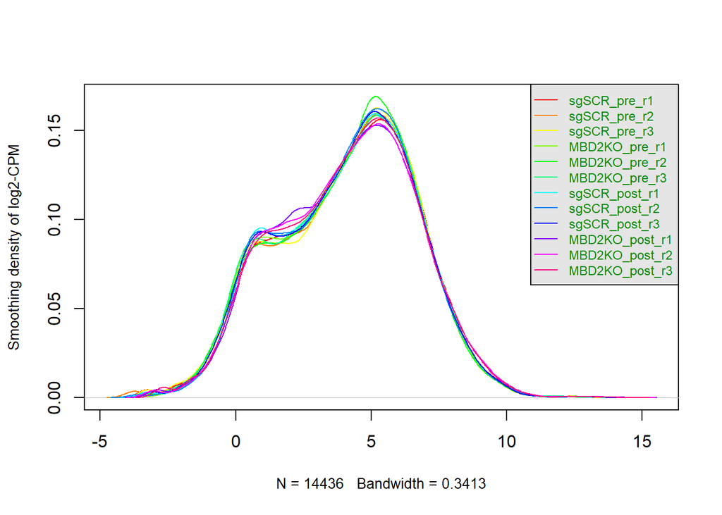

```r
# DENSITY PLOT FOR NORMALIZED DATA
norm_counts_density <- apply(log2(norm_counts),
                        2,
                        density)
#calculate the limits across all the samples
xlim <- 0; ylim <- 0
for (i in 1:length(norm_counts_density)) {
  xlim <- range(c(xlim, norm_counts_density[[i]]$x));
  ylim <- range(c(ylim, norm_counts_density[[i]]$y))
}
cols <- rainbow(length(norm_counts_density))
ltys <- rep(1, length(norm_counts_density))
#plot the first density plot to initialize the plot
plot(norm_counts_density[[1]], xlim=xlim, ylim=ylim, type="n",
     ylab="Smoothing density of log2-CPM", main="", cex.lab = 0.85)
#plot each line
for (i in 1:length(norm_counts_density)) {
  lines(norm_counts_density[[i]], col=cols[i], lty=ltys[i])
}
#create legend
legend("topright", colnames(data2plot),
       col=cols, lty=ltys, cex=0.75,
       border ="blue",  text.col = "green4",
       merge = TRUE, bg = "gray90")
```

## References

[1] Yu, X., Azzo, A., Bilinovich, S. M., Li, X., Dozmorov, M., Kurita, R., Nakamura, Y., Williams, D. C., Ginder, G. D. (2019) Disruption of the MBD2-NuRD Complex But Not MBD3-NuRD Induces High Level HbF Expression in Human Adult Erythroid Cells. Haematologica 104:2361-2371; doi:10.3324/haematol.2018.210963

[2] Davis, S., Meltzer, P. (2007) “GEOquery: a bridge between the Gene Expression Omnibus (GEO) and Bioconductor.” Bioinformatics 14: 1846-1847

[3] Robinson MD, McCarthy DJ and Smyth GK (2010). edgeR: a Bioconductor package for differential expression analysis of digital gene expression data. Bioinformatics 26, 139-140

[4] McCarthy DJ, Chen Y and Smyth GK (2012). Differential expression analysis of multifactor RNA-Seq experiments with respect to biological variation. Nucleic Acids Research 40, 4288-4297

[5] Durinck, S, Spellman, P. T., Birney, E., Huber, w. (2009) Mapping identifiers for the integration of genomic datasets with the R/Bioconductor package biomaRt. Nature Protocols 4, 1184-1191

[6] Dunrinck, W., Moreau, Y., Kasprzyk, A., Davis, S., Moor, B. D., Brazma, A., Huber, W. (2005) BioMart and Bioconductor: a powerful link between biological databases and microarray data analysis. Bioinformatics 21, 3439-3440